# STAT 420 - Group Project - Football analytics based on FIFA 2019 players data

Blake Weston Nicolls (bwn2), Uttam Roy (uroy) and Balaji Sathyamurthy (balajis2) - Group 101

08/01/2019

# Team

- Size : 3
- Details :
1. Balaji, Sathyamurthy (NetID: balajis2)
2. Blake Weston, Nicolls (NetID: bwn2)
3. Uttam, Roy (NetID: uroy)

# Project Title

**Football analytics based on FIFA 2019 players data**

# Introduction

The goal of the project is to be able to build a good model and predict the overall rating of the FIFA players based on their skillset data. With the growing popularity of FIFA, in usa we thought that predicting the player rating based on their skillset, wages and physical factors such as age, height, weight etc., is very interesting.

Also the number of observations we have used is around 18k+ with around 46 predictors to make the model more interesting and at the same time give an accurate prediction. As the quote, “All models are wrong, some models are useful”, our goal is to find a useful model for this dataset which can be used for prediction.

As technology has advanced over the last number of years data collection has become more in-depth and can be conducted with relative ease. Advancements in data collection have allowed for sports analytics to grow as well, leading to the development of advanced statistics as well sport specific technologies that allow for things like game simulations to be conducted by teams prior to play, improve fan acquisition and marketing strategies, and even understand the impact of sponsorship on each team as well as its fans which motivated us to chose this topic for the project.

The dataset is acquired from kaggle website and below is the link: https://www.kaggle.com/karangadiya/fifa19

Some descriptions about the variables of the dataset:

- Overall : overall rating of the player
- Age : age of the player
- heightInch : height of the player in inches
- WeightLbs : weight of the player in lbs
- value_k_eu : value of the player in thousands in euro
- wage_k_eu : wage of the player in thousands in euro
- rel_tot_value_k : release amount of the player in thousands in euro
- PreferredFoot : Preferred foot of the player, it is a factor variable, will be used as dummy variable
- WeakFoot : skillset of week foot
- Position: position of the player, it is a factor variable
- JerseyNumber : Jersey Number of the player

other variables are about skills and self explanatory

**Dataset**

```r
# Loading all necessary Libraries.
library(readr)
library(lmtest)
library(leaps)
library(knitr)
library(ggplot2)
library(faraway)
library(flextable)
library(magrittr)
#install.packages("flextable")
#install.packages("leaps")
```

```r
#Reading the data from the FIFA data file
#FIFA_data = read.csv("FIFA_data.csv",fileEncoding="latin1")
FIFA_data = read.csv("FIFA_data.csv")

#Subsetting the required data (player skillset, wages and physical factors such as age, height,weight etc.,) from the file to a data frame
FIFA=data.frame(Overall=FIFA_data$Overall, value_k_eu   =FIFA_data$value_k_eu,  wage_k_eu =FIFA_data$wage_k_eu, rel_tot_value_k = FIFA_data$rel_tot_value_k,
Age=FIFA_data$Age, PreferredFoot=FIFA_data$PreferredFoot, WeakFoot=FIFA_data$WeakFoot, SkillMoves=FIFA_data$SkillMoves, Position=FIFA_data$Position, JerseyNumber=FIFA_data$JerseyNumber    , heightInch=FIFA_data$heightInch   , WeightLbs=FIFA_data$WeightLbs , Crossing=FIFA_data$Crossing   , Finishing=FIFA_data$Finishing , HeadingAccuracy=FIFA_data$HeadingAccuracy , ShortPassing=FIFA_data$ShortPassing   , Volleys=FIFA_data$Volleys , Dribbling=FIFA_data$Dribbling , Curve=FIFA_data$Curve , FKAccuracy=FIFA_data$FKAccuracy   , LongPassing=FIFA_data$LongPassing , BallControl=FIFA_data$BallControl , Acceleration=FIFA_data$Acceleration   , SprintSpeed=FIFA_data$SprintSpeed , Agility=FIFA_data$Agility , Reactions=FIFA_data$Reactions , Balance=FIFA_data$Balance , ShotPower=FIFA_data$ShotPower , Jumping=FIFA_data$Jumping , Stamina=FIFA_data$Stamina , Strength=FIFA_data$Strength   , LongShots=FIFA_data$LongShots , Aggression=FIFA_data$Aggression   , Interceptions=FIFA_data$Interceptions , Positioning=FIFA_data$Positioning , Vision=FIFA_data$Vision   , Penalties=FIFA_data$Penalties , Composure=FIFA_data$Composure , Marking=FIFA_data$Marking , StandingTackle=FIFA_data$StandingTackle   , SlidingTackle=FIFA_data$SlidingTackle , GKDiving=FIFA_data$GKDiving   , GKHandling=FIFA_data$GKHandling   , GKKicking=FIFA_data$GKKicking , GKPositioning=FIFA_data$GKPositioning , GKReflexes=FIFA_data$GKReflexes)

# We have some observations with missing data about wages, we will remove those as we are intersted to know how the wages effect overall rating
# removing data for 0 rel_tot_value_k , value_k_eu , wage_k_eu
FIFA_data = subset(FIFA_data, rel_tot_value_k > 0)
FIFA_data = subset(FIFA_data, value_k_eu > 0)
FIFA_data = subset(FIFA_data, wage_k_eu > 0)

#Removing all the NA data from the data set
FIFA_data = na.omit(FIFA)
```

A snippet of dataset. (Only first few columns).

| Overall | value_k_eu | wage_k_eu | rel_tot_value_k | Age | PreferredFoot | WeakFoot | SkillMoves | Position | JerseyNumber | heightInch | WeightLbs | Crossing | Finishing | HeadingAccuracy |
| --- | --- | --- | --- | --- | --- | --- | --- | --- | --- | --- | --- | --- | --- | --- |
| 94 | 110500 | 565 | 226500 | 31 | Left | 4 | 4 | RF | 10 | 67 | 159 | 84 | 95 | 70 |
| 94 | 77000 | 405 | 127100 | 33 | Right | 4 | 5 | ST | 7 | 74 | 183 | 84 | 94 | 89 |
| 92 | 118500 | 290 | 228100 | 26 | Right | 5 | 5 | LW | 10 | 69 | 150 | 79 | 87 | 62 |
| 91 | 72000 | 260 | 138600 | 27 | Right | 3 | 1 | GK | 1 | 76 | 168 | 17 | 13 | 21 |
| 91 | 102000 | 355 | 196400 | 27 | Right | 5 | 4 | RCM | 7 | 71 | 154 | 93 | 82 | 55 |
| 91 | 93000 | 340 | 172100 | 27 | Right | 4 | 4 | LF | 10 | 68 | 163 | 81 | 84 | 61 |
| 91 | 67000 | 420 | 137400 | 32 | Right | 4 | 4 | RCM | 10 | 68 | 146 | 86 | 72 | 55 |
| 91 | 80000 | 455 | 164000 | 31 | Right | 4 | 3 | RS | 9 | 72 | 190 | 77 | 93 | 77 |
| 91 | 51000 | 380 | 104600 | 32 | Right | 3 | 3 | RCB | 15 | 72 | 181 | 66 | 60 | 91 |
| 90 | 68000 | 94 | 144500 | 25 | Right | 3 | 1 | GK | 1 | 74 | 192 | 13 | 11 | 15 |

Structure of the dataset :

```r
# Analyzing the structure of the dataset
str(FIFA_data)
```

```
## 'data.frame':    18147 obs. of  46 variables:
##  $ Overall        : int  94 94 92 91 91 91 91 91 91 90 ...
##  $ value_k_eu     : int  110500 77000 118500 72000 102000 93000 67000 80000 51000 68000 ...
##  $ wage_k_eu      : int  565 405 290 260 355 340 420 455 380 94 ...
##  $ rel_tot_value_k: int  226500 127100 228100 138600 196400 172100 137400 164000 104600 144500 ...
##  $ Age            : int  31 33 26 27 27 27 32 31 32 25 ...
##  $ PreferredFoot  : Factor w/ 3 levels "","Left","Right": 2 3 3 3 3 3 3 3 3 3 ...
##  $ WeakFoot       : int  4 4 5 3 5 4 4 4 3 3 ...
##  $ SkillMoves     : int  4 5 5 1 4 4 4 3 3 1 ...
##  $ Position       : Factor w/ 28 levels "","CAM","CB",..: 23 28 16 7 21 13 21 25 20 7 ...
##  $ JerseyNumber   : int  10 7 10 1 7 10 10 9 15 1 ...
##  $ heightInch     : int  67 74 69 76 71 68 68 72 72 74 ...
##  $ WeightLbs      : int  159 183 150 168 154 163 146 190 181 192 ...
##  $ Crossing       : int  84 84 79 17 93 81 86 77 66 13 ...
##  $ Finishing      : int  95 94 87 13 82 84 72 93 60 11 ...
```

[output cut: 34 more lines]

# Methods

We will split the dataset into training and test dataset. We will use 15% data as training data and 85% of data as test data.

```r
# FIFA_DATA has about 18k+  observations, R can not handle all thease data in many different functions, so we will sample some data and work on that
# Sampling 15% of the dataset for modelling
set.seed(420)
fifa_trn_idx  = sample(nrow(FIFA_data), size = trunc(0.15 * nrow(FIFA_data)))

#Split the dataset into training and test dataset
fifa_trn_data = FIFA_data[fifa_trn_idx, ]
fifa_tst_data = FIFA_data[-fifa_trn_idx, ]

#Store the number of observations in a variable
n=nrow(fifa_trn_data)
```

Our initial simple models are :

```r
#Initial large model with all variables and limited interactions between Age,heightInch and WeightLbs with all other variables
model_init = lm(Overall ~  Age+ rel_tot_value_k + value_k_eu + wage_k_eu + PreferredFoot+ WeakFoot+ SkillMoves+  heightInch + WeightLbs + Crossing  + Finishing + HeadingAccuracy   + ShortPassing  + Volleys   + Dribbling + Curve + FKAccuracy    + LongPassing   + BallControl   + Acceleration  + SprintSpeed   + Agility   + Reactions + Balance   + ShotPower + Jumping   + Stamina   + Strength  + LongShots + Aggression    + Interceptions + Positioning   + Vision    + Penalties + Composure + Marking   + StandingTackle    + SlidingTackle + GKDiving  + GKHandling    + GKKicking + GKPositioning + GKReflexes
                + Age:( rel_tot_value_k + value_k_eu + wage_k_eu + PreferredFoot+ WeakFoot+ SkillMoves+  heightInch + WeightLbs + Crossing  + Finishing + HeadingAccuracy   + ShortPassing  + Volleys   + Dribbling + Curve + FKAccuracy    + LongPassing   + BallControl   + Acceleration  + SprintSpeed   + Agility   + Reactions + Balance   + ShotPower + Jumping   + Stamina   + Strength  + LongShots + Aggression    + Interceptions + Positioning   + Vision    + Penalties + Composure + Marking   + StandingTackle    + SlidingTackle + GKDiving  + GKHandling    + GKKicking + GKPositioning + GKReflexes)
                + heightInch:( rel_tot_value_k + value_k_eu + wage_k_eu + Age+ PreferredFoot+ WeakFoot+ SkillMoves+  heightInch + WeightLbs + Crossing  + Finishing + HeadingAccuracy   + ShortPassing  + Volleys   + Dribbling + Curve + FKAccuracy    + LongPassing   + BallControl   + Acceleration  + SprintSpeed   + Agility   + Reactions + Balance   + ShotPower + Jumping   + Stamina   + Strength  + LongShots + Aggression    + Interceptions + Positioning   + Vision    + Penalties + Composure + Marking   + StandingTackle    + SlidingTackle + GKDiving  + GKHandling    + GKKicking + GKPositioning + GKReflexes)
                +WeightLbs:( rel_tot_value_k + value_k_eu + wage_k_eu + Age+ PreferredFoot+ WeakFoot+ SkillMoves+  heightInch   + WeightLbs + Crossing  + Finishing + HeadingAccuracy   + ShortPassing  + Volleys   + Dribbling + Curve + FKAccuracy    + LongPassing   + BallControl   + Acceleration  + SprintSpeed   + Agility   + Reactions + Balance   + ShotPower + Jumping   + Stamina   + Strength  + LongShots + Aggression    + Interceptions + Positioning   + Vision    + Penalties + Composure + Marking   + StandingTackle    + SlidingTackle + GKDiving  + GKHandling    + GKKicking + GKPositioning + GKReflexes)
                + Age:heightInch:WeightLbs,
            data = fifa_trn_data)

#Simple model with no interactions between Age,heightInch and WeightLbs with all other variables
model_simple = lm(Overall ~  Age+ rel_tot_value_k + value_k_eu + wage_k_eu + PreferredFoot+ WeakFoot+ SkillMoves+ heightInch    + WeightLbs + Crossing  + Finishing + HeadingAccuracy   + ShortPassing  + Volleys   + Dribbling + Curve + FKAccuracy    + LongPassing   + BallControl   + Acceleration  + SprintSpeed   + Agility   + Reactions + Balance   + ShotPower + Jumping   + Stamina   + Strength  + LongShots + Aggression    + Interceptions + Positioning   + Vision    + Penalties + Composure + Marking   + StandingTackle    + SlidingTackle + GKDiving  + GKHandling    + GKKicking + GKPositioning + GKReflexes ,
            data = fifa_trn_data)

#Comparing the simple and large model
pvalue = anova(model_simple,model_init)["2","Pr(>F)"]
```

The p-value is very small 8.649510^{-104} and at an $\alpha$ level of 0.01, we reject the null hypothesis and prefer the larger complex model.

Next we will check the variance and normality of the complex model:

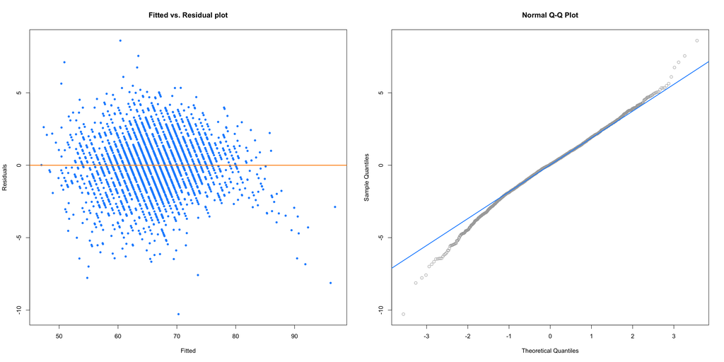

```r
# Check for the variance and normality for the initial large model using the plots

par(mfrow=c(1,2))
plot(fitted(model_init), resid(model_init), col = "dodgerblue", pch = 20, xlab = "Fitted", ylab = "Residuals", main = "Fitted vs. Residual plot")
abline(h = 0, col = "darkorange", lwd = 2)

qqnorm(resid(model_init), main = "Normal Q-Q Plot", col = "darkgrey")
qqline(resid(model_init), col = "dodgerblue", lwd = 2)
```

```r
bptest_value = bptest(model_init)$p.value
shp_test_value = shapiro.test(resid(model_init))$p.value
```

The Fitted vs. Residuals and Normal QQ plots are not ok.

Also looking at the BP Test and Shapiro Wilk Test

1. BP Test (p-value) = 4.195310^{-11}
2. Shapiro Wilk test (p-value) = 1.281610^{-10}

suggests the data is not from equal variance and normal distribution.

Next we will check the collinearity of the predictors to find best usefull predictors using variance inflation factor. We will remove the predictors with high collinearity.

```r
#Trying to find a model using VIF
vif(model_simple)[which(faraway::vif(model_simple) < 5)]
```

```
##                Age          wage_k_eu PreferredFootRight           WeakFoot
##              1.977              4.273              1.109              1.222
##         SkillMoves         heightInch          WeightLbs            Agility
##              3.873              4.126              3.152              4.704
##          Reactions            Balance            Jumping            Stamina
##              3.313              4.672              1.581              3.828
##           Strength         Aggression             Vision          Penalties
##              3.305              3.699              4.549              4.616
##          Composure
##              3.491
```

```r
#Building a simple model using the VIF variables
model_simple1= lm( Overall ~ wage_k_eu
                   + Age + heightInch + WeightLbs
                   + PreferredFoot + WeakFoot
                   + SkillMoves + Agility + Reactions + Balance + Jumping + Stamina + Strength + Aggression +
                     Vision + Penalties + Composure,data = fifa_trn_data)

#Building a complex model based on simple model and interaction between the variables - wage_k_eu,Age,heightInch,WeightLbs #and wage_k_eu with other variables

model_init1 =  lm( Overall ~ wage_k_eu
                              + Age + heightInch + WeightLbs
                              + PreferredFoot + WeakFoot
                              + SkillMoves + Agility + Reactions + Balance + Jumping + Stamina + Strength + Aggression + Vision + Penalties                               + Composure
                              + wage_k_eu : ( Age + heightInch + WeightLbs
                              + PreferredFoot + WeakFoot
                              + SkillMoves + Agility + Reactions + Balance + Jumping + Stamina + Strength + Aggression + Vision + Penalties                                + Composure )
                            + Age:(wage_k_eu + heightInch + WeightLbs
                              + PreferredFoot + WeakFoot
                              + SkillMoves + Agility + Reactions + Balance + Jumping + Stamina + Strength + Aggression + Vision + Penalties                               +Composure )
                            + heightInch: (Age + wage_k_eu + WeightLbs
                              + PreferredFoot + WeakFoot
                              + SkillMoves + Agility + Reactions + Balance + Jumping + Stamina + Strength + Aggression + Vision + Penalties                               +Composure )
                            + WeightLbs: (Age + wage_k_eu +  heightInch
                              + PreferredFoot + WeakFoot
                              + SkillMoves + Agility + Reactions + Balance + Jumping + Stamina + Strength + Aggression + Vision + Penalties                               +Composure )
                            + wage_k_eu:Age:heightInch + wage_k_eu:Age:WeightLbs + Age:heightInch:WeightLbs + wage_k_eu:Age:heightInch:WeightLbs
                   ,
                   data = fifa_trn_data)

#Comparing the 3 models using anova
anova(model_simple,model_simple1)
```

```
## Analysis of Variance Table
##
## Model 1: Overall ~ Age + rel_tot_value_k + value_k_eu + wage_k_eu + PreferredFoot +
##     WeakFoot + SkillMoves + heightInch + WeightLbs + Crossing +
##     Finishing + HeadingAccuracy + ShortPassing + Volleys + Dribbling +
##     Curve + FKAccuracy + LongPassing + BallControl + Acceleration +
##     SprintSpeed + Agility + Reactions + Balance + ShotPower +
##     Jumping + Stamina + Strength + LongShots + Aggression + Interceptions +
##     Positioning + Vision + Penalties + Composure + Marking +
##     StandingTackle + SlidingTackle + GKDiving + GKHandling +
##     GKKicking + GKPositioning + GKReflexes
## Model 2: Overall ~ wage_k_eu + Age + heightInch + WeightLbs + PreferredFoot +
##     WeakFoot + SkillMoves + Agility + Reactions + Balance + Jumping +
##     Stamina + Strength + Aggression + Vision + Penalties + Composure
##   Res.Df   RSS  Df Sum of Sq    F Pr(>F)
## 1   2678 15093
## 2   2704 25416 -26    -10324 70.5 <2e-16 ***
## ---
## Signif. codes:  0 '***' 0.001 '**' 0.01 '*' 0.05 '.' 0.1 ' ' 1
```

```r
anova(model_simple1,model_init1)
```

```
## Analysis of Variance Table
##
## Model 1: Overall ~ wage_k_eu + Age + heightInch + WeightLbs + PreferredFoot +
##     WeakFoot + SkillMoves + Agility + Reactions + Balance + Jumping +
##     Stamina + Strength + Aggression + Vision + Penalties + Composure
## Model 2: Overall ~ wage_k_eu + Age + heightInch + WeightLbs + PreferredFoot +
##     WeakFoot + SkillMoves + Agility + Reactions + Balance + Jumping +
##     Stamina + Strength + Aggression + Vision + Penalties + Composure +
##     wage_k_eu:(Age + heightInch + WeightLbs + PreferredFoot +
##         WeakFoot + SkillMoves + Agility + Reactions + Balance +
##         Jumping + Stamina + Strength + Aggression + Vision +
##         Penalties + Composure) + Age:(wage_k_eu + heightInch +
##     WeightLbs + PreferredFoot + WeakFoot + SkillMoves + Agility +
##     Reactions + Balance + Jumping + Stamina + Strength + Aggression +
##     Vision + Penalties + Composure) + heightInch:(Age + wage_k_eu +
##     WeightLbs + PreferredFoot + WeakFoot + SkillMoves + Agility +
##     Reactions + Balance + Jumping + Stamina + Strength + Aggression +
##     Vision + Penalties + Composure) + WeightLbs:(Age + wage_k_eu +
##     heightInch + PreferredFoot + WeakFoot + SkillMoves + Agility +
##     Reactions + Balance + Jumping + Stamina + Strength + Aggression +
##     Vision + Penalties + Composure) + wage_k_eu:Age:heightInch +
##     wage_k_eu:Age:WeightLbs + Age:heightInch:WeightLbs + wage_k_eu:Age:heightInch:WeightLbs
##   Res.Df   RSS Df Sum of Sq  F Pr(>F)
## 1   2704 25416
## 2   2642 19483 62      5933 13 <2e-16 ***
## ---
## Signif. codes:  0 '***' 0.001 '**' 0.01 '*' 0.05 '.' 0.1 ' ' 1
```

Based on the anova test, the larger model after removing collinearity is significant. We will again check the variance and normality of the model:

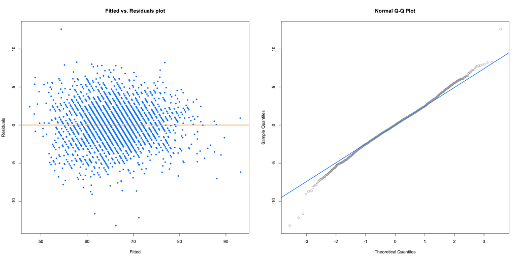

```r
# Check for the variance and normality for the initial large model using the plots

par(mfrow=c(1,2))

plot(fitted(model_init1), resid(model_init1), col = "dodgerblue", pch = 20, xlab = "Fitted", ylab = "Residuals", main = "Fitted vs. Residuals plot")
abline(h = 0, col = "darkorange", lwd = 2)

qqnorm(resid(model_init1), main = "Normal Q-Q Plot", col = "darkgrey")
qqline(resid(model_init1), col = "dodgerblue", lwd = 2)
```

```r
bptst_value = bptest(model_init1)$p.value
shptst_value = shapiro.test(resid(model_init1))$p.value
```

The Fitted vs. Residuals and Normal QQ plots are not ok.

Also looking at the BP Test and Shapiro Wilk Test

1. BP Test (p-value) = 6.940610^{-12}
2. Shapiro Wilk test (p-value) = 5.444810^{-7}

suggests the data is not from equal variance and normal distribution.

Next we will check for unusal observations using influential and outliners method:

```r
# checking influential and outliers points and removing them from the dataset

influential_points = cooks.distance(model_init1) < 4 / length(cooks.distance(model_init1))
outliers = abs(rstandard(model_init1)) > 2

remove_points = c(influential_points,outliers)

fifa_trn_data2=  subset(fifa_trn_data,remove_points)
nrow(fifa_trn_data2)
```

```
## [1] 2674
```

```r
#Model using the dataset with the influential and outliers points removed

model_simple2= lm( Overall ~ wage_k_eu
                              + Age + heightInch + WeightLbs
                              + PreferredFoot + WeakFoot
                              + SkillMoves + Agility + Reactions + Balance + Jumping + Stamina + Strength + Aggression + Vision + Penalties                               + Composure,
                              data = fifa_trn_data2)

model_init2 =  lm( Overall ~ wage_k_eu
                              + Age + heightInch + WeightLbs
                              + PreferredFoot + WeakFoot
                              + SkillMoves + Agility + Reactions + Balance + Jumping + Stamina + Strength + Aggression + Vision + Penalties                               + Composure
                              + wage_k_eu : ( Age + heightInch + WeightLbs
                              + PreferredFoot + WeakFoot
                              + SkillMoves + Agility + Reactions + Balance + Jumping + Stamina + Strength + Aggression + Vision + Penalties                               + Composure )
                              + Age:(wage_k_eu + heightInch + WeightLbs
                              + PreferredFoot + WeakFoot
                              + SkillMoves + Agility + Reactions + Balance + Jumping + Stamina + Strength + Aggression + Vision + Penalties                               + Composure )
                              + heightInch: (Age + wage_k_eu + WeightLbs
                              + PreferredFoot + WeakFoot
                              + SkillMoves + Agility + Reactions + Balance + Jumping + Stamina + Strength + Aggression + Vision + Penalties                               + Composure )
                              + WeightLbs: (Age + wage_k_eu +  heightInch
                              + PreferredFoot + WeakFoot
                              + SkillMoves + Agility + Reactions + Balance + Jumping + Stamina + Strength + Aggression + Vision + Penalties                               + Composure )
                              + wage_k_eu:Age:heightInch + wage_k_eu:Age:WeightLbs + Age:heightInch:WeightLbs +
                               wage_k_eu:Age:heightInch:WeightLbs,
                               data = fifa_trn_data2)
```

Now we will check the variance and normality of the model and new data:

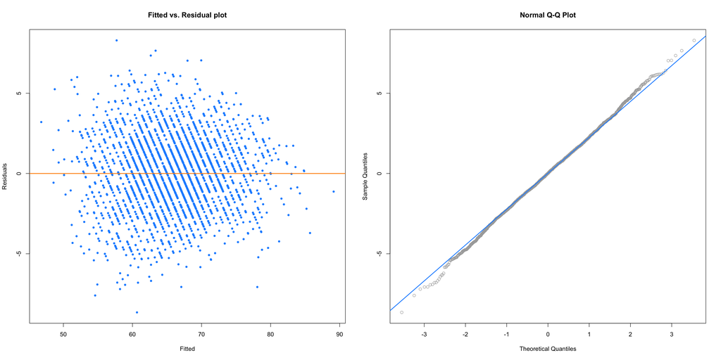

```r
#Plotting to check for equal variance and normal distribution
par(mfrow=c(1,2))
plot(fitted(model_init2), resid(model_init2), col = "dodgerblue", pch = 20, xlab = "Fitted", ylab = "Residuals", main = "Fitted vs. Residual plot")
abline(h = 0, col = "darkorange", lwd = 2)

qqnorm(resid(model_init2), main = "Normal Q-Q Plot", col = "darkgrey")
qqline(resid(model_init2), col = "dodgerblue", lwd = 2)
```

```r
bptst_value = bptest(model_init2)$p.value
shptst_value = shapiro.test(resid(model_init2))$p.value

n=nrow(fifa_trn_data2)
```

The Fitted vs. Residuals and Normal QQ plots are much better now.

Also looking at the BP Test and Shapiro Wilk Test

1. BP Test (p-value) = 2.169310^{-6}
2. Shapiro Wilk test (p-value) = 0.5202

Shapiro Wilk test is passed now which suggests normality whereas the BP test is getting failed. Since it is a large dataset, we are making an assumption based on the fitted vs. residual that its of equal variance.

```r
anova(model_simple2,model_init2)
```

```
## Analysis of Variance Table
##
## Model 1: Overall ~ wage_k_eu + Age + heightInch + WeightLbs + PreferredFoot +
##     WeakFoot + SkillMoves + Agility + Reactions + Balance + Jumping +
##     Stamina + Strength + Aggression + Vision + Penalties + Composure
## Model 2: Overall ~ wage_k_eu + Age + heightInch + WeightLbs + PreferredFoot +
##     WeakFoot + SkillMoves + Agility + Reactions + Balance + Jumping +
##     Stamina + Strength + Aggression + Vision + Penalties + Composure +
##     wage_k_eu:(Age + heightInch + WeightLbs + PreferredFoot +
##         WeakFoot + SkillMoves + Agility + Reactions + Balance +
##         Jumping + Stamina + Strength + Aggression + Vision +
##         Penalties + Composure) + Age:(wage_k_eu + heightInch +
##     WeightLbs + PreferredFoot + WeakFoot + SkillMoves + Agility +
##     Reactions + Balance + Jumping + Stamina + Strength + Aggression +
##     Vision + Penalties + Composure) + heightInch:(Age + wage_k_eu +
##     WeightLbs + PreferredFoot + WeakFoot + SkillMoves + Agility +
##     Reactions + Balance + Jumping + Stamina + Strength + Aggression +
##     Vision + Penalties + Composure) + WeightLbs:(Age + wage_k_eu +
##     heightInch + PreferredFoot + WeakFoot + SkillMoves + Agility +
##     Reactions + Balance + Jumping + Stamina + Strength + Aggression +
##     Vision + Penalties + Composure) + wage_k_eu:Age:heightInch +
##     wage_k_eu:Age:WeightLbs + Age:heightInch:WeightLbs + wage_k_eu:Age:heightInch:WeightLbs
##   Res.Df   RSS Df Sum of Sq    F Pr(>F)
## 1   2520 18890
## 2   2458 13682 62      5208 15.1 <2e-16 ***
## ---
## Signif. codes:  0 '***' 0.001 '**' 0.01 '*' 0.05 '.' 0.1 ' ' 1
```

The anova test suggests the larger model is significant.

Next we will find best predictors of this model using Akaike Information Criterion (AIC) and Bayesian Information Criterion (BIC) methods:

```r
#Using the model search to find the best model
n=nrow(fifa_trn_data2)
model_aic=step(model_init2, direction = "backward", trace=0)
model_bic=step(model_init2, direction = "backward", k=log(n), trace=0)

p=length(coef(model_aic))
rss = sum((resid(model_aic))^2)
value_model_aic = n * log(rss/n) + 2*p
value_model_aic
```

```
## [1] 4484
```

```r
p=length(coef(model_bic))
rss = sum((resid(model_bic))^2)
value_model_bic = n * log(rss/n) + log(n)*p
value_model_bic
```

```
## [1] 4721
```

```r
min(value_model_aic,value_model_bic)
```

```
## [1] 4484
```

```r
summary(model_aic)
```

```
##
## Call:
## lm(formula = Overall ~ wage_k_eu + Age + heightInch + WeightLbs +
##     PreferredFoot + WeakFoot + SkillMoves + Agility + Reactions +
##     Balance + Jumping + Stamina + Strength + Aggression + Vision +
##     Penalties + Composure + wage_k_eu:Age + wage_k_eu:heightInch +
##     wage_k_eu:WeakFoot + wage_k_eu:SkillMoves + wage_k_eu:Agility +
##     wage_k_eu:Reactions + wage_k_eu:Balance + wage_k_eu:Jumping +
##     wage_k_eu:Strength + wage_k_eu:Aggression + wage_k_eu:Composure +
##     Age:heightInch + Age:WeightLbs + Age:PreferredFoot + Age:Reactions +
##     Age:Balance + Age:Strength + Age:Vision + Age:Composure +
##     heightInch:WeightLbs + heightInch:PreferredFoot + heightInch:WeakFoot +
##     heightInch:SkillMoves + heightInch:Reactions + heightInch:Balance +
##     heightInch:Stamina + heightInch:Aggression + WeightLbs:Agility +
##     WeightLbs:Reactions + WeightLbs:Jumping + WeightLbs:Stamina +
##     WeightLbs:Strength + WeightLbs:Vision + WeightLbs:Penalties,
##     data = fifa_trn_data2)
##
## Residuals:
##    Min     1Q Median     3Q    Max
## -8.724 -1.509  0.014  1.534  8.307
##
## Coefficients:
##                                Estimate Std. Error t value Pr(>|t|)
## (Intercept)                   -1.06e+02   3.21e+01   -3.31  0.00094 ***
## wage_k_eu                      1.28e+00   2.48e-01    5.18  2.4e-07 ***
## Age                           -6.59e-01   5.97e-01   -1.10  0.26945
## heightInch                     1.46e+00   4.64e-01    3.15  0.00167 **
## WeightLbs                      7.79e-01   1.60e-01    4.87  1.2e-06 ***
## PreferredFootRight            -1.00e+01   3.14e+00   -3.18  0.00147 **
## WeakFoot                       3.90e+00   2.14e+00    1.83  0.06766 .
## SkillMoves                     1.18e+01   3.00e+00    3.92  9.2e-05 ***
## Agility                        2.55e-01   6.38e-02    4.00  6.5e-05 ***
## Reactions                     -5.66e-01   2.56e-01   -2.21  0.02733 *
## Balance                        2.60e-01   1.48e-01    1.76  0.07900 .
## Jumping                       -1.86e-01   4.87e-02   -3.82  0.00014 ***
## Stamina                        6.57e-01   1.45e-01    4.54  6.0e-06 ***
## Strength                       5.36e-02   6.42e-02    0.84  0.40369
## Aggression                    -3.59e-01   1.12e-01   -3.20  0.00140 **
## Vision                         2.61e-01   6.32e-02    4.14  3.7e-05 ***
```

[output cut: 28 more lines]

```
## heightInch:Aggression          5.11e-03   1.58e-03    3.24  0.00120 **
## WeightLbs:Agility             -1.49e-03   3.81e-04   -3.91  9.3e-05 ***
## WeightLbs:Reactions            2.04e-03   7.54e-04    2.70  0.00698 **
## WeightLbs:Jumping              1.23e-03   2.92e-04    4.22  2.5e-05 ***
## WeightLbs:Stamina             -8.32e-04   4.33e-04   -1.92  0.05507 .
## WeightLbs:Strength             5.51e-04   3.78e-04    1.46  0.14445
## WeightLbs:Vision              -1.02e-03   3.68e-04   -2.76  0.00580 **
## WeightLbs:Penalties           -9.72e-04   3.09e-04   -3.15  0.00167 **
## ---
## Signif. codes:  0 '***' 0.001 '**' 0.01 '*' 0.05 '.' 0.1 ' ' 1
##
## Residual standard error: 2.35 on 2486 degrees of freedom
##   (136 observations deleted due to missingness)
## Multiple R-squared:  0.871,  Adjusted R-squared:  0.869
## F-statistic:  330 on 51 and 2486 DF,  p-value: <2e-16
```

Based on the AIC/BIC, AIC model is better for this dataset.

Since we have so many predictors and interactions between predictors, we are not going for transformations and polynomial regression, that will make the model very complex.

# Results

We will compare the result of bp-test, Shapiro-Wilk test, LOOCV-rmse between different models derived from above methods:

```r
#Model Comparison based on Adjusted RMSE, loocv_RMSE,Shapiro Wilk and BP test

calc_RMSE = function(origin_data,predicted_data) {
      sqrt(mean((origin_data - predicted_data)^2))
  }

calc_loocv_rmse = function(model){
  sqrt(mean((resid(model)/(1-hatvalues(model)))^2))
}

FIFA_train_clean_data = fifa_trn_data2
FIFA_test_data = fifa_tst_data # 85% of origanl dataset

#Basic Model
basic_model = lm(Overall ~  Age+ rel_tot_value_k + value_k_eu + wage_k_eu + PreferredFoot+ WeakFoot
                            + SkillMoves+  heightInch   + WeightLbs + Crossing  + Finishing + HeadingAccuracy   + ShortPassing  + Volleys   + Dribbling + Curve + FKAccuracy                     + LongPassing  + BallControl   + Acceleration  + SprintSpeed   + Agility   + Reactions + Balance   + ShotPower +                       Jumping + Stamina   + Strength  + LongShots + Aggression    + Interceptions + Positioning   + Vision    + Penalties +                   Composure   + Marking   + StandingTackle    + SlidingTackle + GKDiving  + GKHandling    + GKKicking + GKPositioning +                   GKReflexes + Age:( rel_tot_value_k + value_k_eu + wage_k_eu + PreferredFoot+ WeakFoot+ SkillMoves+  heightInch                   + WeightLbs    + Crossing  + Finishing + HeadingAccuracy   + ShortPassing  + Volleys   + Dribbling + Curve +                         FKAccuracy    + LongPassing   + BallControl   + Acceleration  + SprintSpeed   + Agility   + Reactions + Balance   +                         ShotPower + Jumping   + Stamina   + Strength  + LongShots + Aggression    + Interceptions + Positioning   + Vision    +                   Penalties   + Composure + Marking   + StandingTackle    + SlidingTackle + GKDiving  + GKHandling    + GKKicking +                       GKPositioning   + GKReflexes)
                + heightInch:( rel_tot_value_k + value_k_eu + wage_k_eu + Age+ PreferredFoot+ WeakFoot+ SkillMoves+  heightInch                 + WeightLbs + Crossing  + Finishing + HeadingAccuracy   + ShortPassing  + Volleys   + Dribbling + Curve + FKAccuracy                    + LongPassing   + BallControl   + Acceleration  + SprintSpeed   + Agility   + Reactions + Balance   + ShotPower + Jumping                   + Stamina   + Strength  + LongShots + Aggression    + Interceptions + Positioning   + Vision    + Penalties + Composure                 + Marking   + StandingTackle    + SlidingTackle + GKDiving  + GKHandling    + GKKicking + GKPositioning + GKReflexes)
                + WeightLbs:( rel_tot_value_k + value_k_eu + wage_k_eu + Age+ PreferredFoot+ WeakFoot+ SkillMoves+  heightInch                  + WeightLbs + Crossing  + Finishing + HeadingAccuracy   + ShortPassing  + Volleys   + Dribbling + Curve + FKAccuracy                    + LongPassing   + BallControl   + Acceleration  + SprintSpeed   + Agility   + Reactions + Balance   + ShotPower + Jumping                   + Stamina   + Strength  + LongShots + Aggression    + Interceptions + Positioning   + Vision    + Penalties + Composure                 + Marking   + StandingTackle    + SlidingTackle + GKDiving  + GKHandling    + GKKicking + GKPositioning + GKReflexes)
                + Age:heightInch:WeightLbs,data = fifa_trn_data)

#Model with colinearity variables removed
colinearity_removed_model = lm( Overall ~ wage_k_eu
                              + Age + heightInch + WeightLbs
                              + PreferredFoot + WeakFoot
                              + SkillMoves + Agility + Reactions + Balance + Jumping + Stamina + Strength + Aggression + Vision                               + Penalties                               + Composure
                              + wage_k_eu : ( Age + heightInch + WeightLbs
                              + PreferredFoot + WeakFoot
                              + SkillMoves + Agility + Reactions + Balance + Jumping + Stamina + Strength + Aggression + Vision                               + Penalties                                + Composure )
                              + Age:(wage_k_eu + heightInch + WeightLbs
                              + PreferredFoot + WeakFoot
                              + SkillMoves + Agility + Reactions + Balance + Jumping + Stamina + Strength + Aggression + Vision                               + Penalties + Composure )
                              + heightInch: (Age + wage_k_eu + WeightLbs
                              + PreferredFoot + WeakFoot
                              + SkillMoves + Agility + Reactions + Balance + Jumping + Stamina + Strength + Aggression + Vision                               + Penalties +Composure )
                              + WeightLbs: (Age + wage_k_eu +  heightInch
                              + PreferredFoot + WeakFoot
                              + SkillMoves + Agility + Reactions + Balance + Jumping + Stamina + Strength + Aggression + Vision                               + Penalties                               +Composure )
                              + wage_k_eu:Age:heightInch + wage_k_eu:Age:WeightLbs + Age:heightInch:WeightLbs +
                                wage_k_eu:Age:heightInch:WeightLbs,
                              data = fifa_trn_data)

#Model with influential / outlier points removed
influ_out_removed_model    = lm( Overall ~ wage_k_eu
                              + Age + heightInch + WeightLbs
                              + PreferredFoot + WeakFoot
                              + SkillMoves + Agility + Reactions + Balance + Jumping + Stamina + Strength + Aggression + Vision                               + Penalties                               + Composure
                              + wage_k_eu : ( Age + heightInch + WeightLbs
                              + PreferredFoot + WeakFoot
                              + SkillMoves + Agility + Reactions + Balance + Jumping + Stamina + Strength + Aggression + Vision                               + Penalties                                + Composure )
                              + Age:(wage_k_eu + heightInch + WeightLbs
                              + PreferredFoot + WeakFoot
                              + SkillMoves + Agility + Reactions + Balance + Jumping + Stamina + Strength + Aggression + Vision                               + Penalties + Composure )
                              + heightInch: (Age + wage_k_eu + WeightLbs
                              + PreferredFoot + WeakFoot
                              + SkillMoves + Agility + Reactions + Balance + Jumping + Stamina + Strength + Aggression + Vision                               + Penalties +Composure )
                              + WeightLbs: (Age + wage_k_eu +  heightInch
                              + PreferredFoot + WeakFoot
                              + SkillMoves + Agility + Reactions + Balance + Jumping + Stamina + Strength + Aggression + Vision                               + Penalties                               +Composure )
                              + wage_k_eu:Age:heightInch + wage_k_eu:Age:WeightLbs + Age:heightInch:WeightLbs +
                                wage_k_eu:Age:heightInch:WeightLbs,
                              data = FIFA_train_clean_data)

#Model based on backward AIC search
AIC_model = lm(formula = Overall ~ wage_k_eu + Age + heightInch + WeightLbs +
              PreferredFoot + WeakFoot + SkillMoves + Agility + Reactions +
              Balance + Jumping + Stamina + Strength + Aggression + Vision +
              Penalties + Composure + wage_k_eu:Age + wage_k_eu:heightInch +
              wage_k_eu:WeakFoot + wage_k_eu:SkillMoves + wage_k_eu:Agility +
              wage_k_eu:Reactions + wage_k_eu:Balance + wage_k_eu:Jumping +
              wage_k_eu:Strength + wage_k_eu:Aggression + wage_k_eu:Composure +
              Age:heightInch + Age:WeightLbs + Age:PreferredFoot + Age:Reactions +
              Age:Balance + Age:Strength + Age:Vision + Age:Composure +
              heightInch:WeightLbs + heightInch:PreferredFoot + heightInch:WeakFoot +
              heightInch:SkillMoves + heightInch:Reactions + heightInch:Balance +
              heightInch:Stamina + heightInch:Aggression + WeightLbs:Agility +
              WeightLbs:Reactions + WeightLbs:Jumping + WeightLbs:Stamina +
              WeightLbs:Strength + WeightLbs:Vision + WeightLbs:Penalties,
              data = FIFA_train_clean_data)

#Model based on backward BIC search
BIC_model = lm(formula = Overall ~ wage_k_eu + Age + heightInch + WeightLbs +
            PreferredFoot + SkillMoves + Agility + Reactions + Balance +
            Jumping + Stamina + Strength + Aggression + Vision + Penalties +
            Composure + wage_k_eu:Reactions + wage_k_eu:Composure + Age:PreferredFoot +
            Age:Reactions + Age:Balance + Age:Strength + Age:Vision +
            heightInch:WeightLbs + heightInch:SkillMoves + heightInch:Reactions +
            heightInch:Stamina + heightInch:Aggression + WeightLbs:Agility +
            WeightLbs:Jumping + WeightLbs:Penalties, data = FIFA_train_clean_data)

#Computing the adjusted R2 for all the models
r_2 = c(summary(basic_model)$adj.r.squared,summary(colinearity_removed_model)$adj.r.squared,
        summary(influ_out_removed_model)$adj.r.squared,summary(AIC_model)$adj.r.squared,
        summary(BIC_model)$adj.r.squared)

#Computing the shapiro wilk test results for all the models
shapiro = c(shapiro.test(resid(basic_model))$p.value,
            shapiro.test(resid(colinearity_removed_model))$p.value,
            shapiro.test(resid(influ_out_removed_model))$p.value,
            shapiro.test(resid(AIC_model))$p.value,
            shapiro.test(resid(BIC_model))$p.value)

#Computing the bp Test results for all the models
bp_test = c(bptest(basic_model)$p.value,
            bptest(colinearity_removed_model)$p.value,
            bptest(influ_out_removed_model)$p.value,
            bptest(AIC_model)$p.value,
            bptest(BIC_model)$p.value
            )
#Computing the LOOCV RMSE for all the models
loocv_rmse = c(calc_loocv_rmse(basic_model),calc_loocv_rmse(colinearity_removed_model),calc_loocv_rmse(influ_out_removed_model),calc_loocv_rmse(AIC_model),calc_loocv_rmse(BIC_model))

Model_name = c("Basic Model", "Colinearity Removed", "Influ/Outlier removed", "AIC", "BIC")
results = data.frame(Model_name ,r_2, shapiro, bp_test, loocv_rmse)
colnames(results) = c("Model",expression(R^2), "Normality", "Constant Variance", "RMSE (LOOCV)")
flextable(results)
```

| Model | R^2 | Normality | Constant Variance | RMSE (LOOCV) |
| --- | --- | --- | --- | --- |
| Basic Model | 0.910 | 0.000 | 0.000 | 2.194 |
| Colinearity Removed | 0.845 | 0.000 | 0.000 | 2.812 |
| Influ/Outlier removed | 0.868 | 0.520 | 0.000 | 2.390 |
| AIC | 0.869 | 0.562 | 0.000 | 2.374 |
| BIC | 0.865 | 0.747 | 0.000 | 2.395 |

# Discussion

We will validate our model on test data which we created as 85% of the dataset. We will calculate RMSE and check the result:

```r
## Test Validation

rsme_trn_basic = sqrt( (mean(((fifa_trn_data$Overall -  predict(basic_model, newdata=fifa_trn_data)))^2)))
rsme_tst_basic = sqrt( (mean(((fifa_tst_data$Overall -  predict(basic_model, newdata=fifa_tst_data)))^2)))

rsme_trn_col = sqrt( (mean(((fifa_trn_data$Overall -  predict(colinearity_removed_model, newdata=fifa_trn_data)))^2)))
rsme_tst_col = sqrt( (mean(((fifa_tst_data$Overall -  predict(colinearity_removed_model, newdata=fifa_tst_data)))^2)))

rsme_trn_inf = sqrt( (mean(((fifa_trn_data$Overall -  predict(influ_out_removed_model, newdata=fifa_trn_data)))^2)))
rsme_tst_inf = sqrt( (mean(((fifa_tst_data$Overall -  predict(influ_out_removed_model, newdata=fifa_tst_data)))^2)))

rsme_trn_aic = sqrt( (mean(((fifa_trn_data$Overall -  predict(AIC_model, newdata=fifa_trn_data)))^2)))
rsme_tst_aic = sqrt( (mean(((fifa_tst_data$Overall -  predict(AIC_model, newdata=fifa_tst_data)))^2)))

rsme_trn_bic = sqrt( (mean(((fifa_trn_data$Overall -  predict(BIC_model, newdata=fifa_trn_data)))^2)))
rsme_tst_bic = sqrt( (mean(((fifa_tst_data$Overall -  predict(BIC_model, newdata=fifa_tst_data)))^2)))

rmse_data = data.frame(
  model_name = c("Basic Model","Colinearity removed","Influential Removed", "BIC", "AIC"),
  train_rsme = c(rsme_trn_basic,rsme_trn_col,rsme_trn_inf,rsme_trn_aic,rsme_trn_bic),
  test_rsme = c(rsme_tst_basic,rsme_tst_col,rsme_tst_inf,rsme_tst_aic,rsme_tst_bic),
  diff_rmse = c(rsme_trn_basic-rsme_tst_basic,rsme_trn_col-rsme_tst_col,rsme_trn_inf-rsme_tst_inf,rsme_trn_aic-rsme_tst_aic,rsme_trn_bic-rsme_tst_bic)
)

train_rsme = c(rsme_trn_basic,rsme_trn_col,rsme_trn_inf,rsme_trn_aic,rsme_trn_bic)
test_rsme = c(rsme_tst_basic,rsme_tst_col,rsme_tst_inf,rsme_tst_aic,rsme_tst_bic)
diff_rmse = c(rsme_trn_basic-rsme_tst_basic,rsme_trn_col-rsme_tst_col,rsme_trn_inf-rsme_tst_inf,rsme_trn_aic-rsme_tst_aic,rsme_trn_bic-rsme_tst_bic)

Model_name = c("Basic Model","Colinearity removed","Influential Removed", "AIC", "BIC")
results = data.frame(Model_name ,train_rsme, test_rsme, diff_rmse)
colnames(results) = c("Model","Train RMSE","Test RMSE","Train - Test RMSE")
flextable(results)
```

| Model | Train RMSE | Test RMSE | Train - Test RMSE |
| --- | --- | --- | --- |
| Basic Model | 2.011 | 2.228 | -0.217 |
| Colinearity removed | 2.675 | 2.780 | -0.105 |
| Influential Removed | 2.795 | 2.866 | -0.072 |
| AIC | 2.750 | 2.878 | -0.128 |
| BIC | 2.865 | 2.833 | 0.032 |

```r
predicted_test = predict(model_aic,fifa_tst_data)
predicted_data = data.frame(original_Overall = fifa_tst_data$Overall, predicted_overall=predicted_test, difference=(fifa_tst_data$Overall - predicted_test))
sample_test_indx= sample(nrow(predicted_data), size = trunc(0.01 * nrow(predicted_data)))
sample_test_predicted_data=predicted_data[sample_test_indx,]
#View(sample_test_predicted_data)
head(sample_test_predicted_data, n=10)
```

```
##       original_Overall predicted_overall difference
## 7962                67             65.92    1.07759
## 1418                76             76.53   -0.53270
## 2590                74             77.01   -3.01259
## 1425                76             73.83    2.16804
## 9984                65             63.87    1.13305
## 678                 79             72.45    6.55054
## 5513                70             67.43    2.56544
## 2371                74             73.93    0.07488
## 11585               64             67.67   -3.67017
## 13875               62             61.47    0.52756
```

We were able to find a model that is able to satisfy high adjusted R^2,Normality and low RMSE though the model didn’t satisfy the constant variance assumption. Given the fact the residual vs. fitted plot looks good for the model and also the dataset is very huge the constance variance is not getting satisfied in any model so we were able to find a model that can only satisfy R^2, Normality and LOOCV RMSE.

The theme of this class has been, ‘All models are wrong, some are useful’. This summarizes what we discovered in this project.

# Appendix

Model Summaries:

```r
summary(model_aic)
```

```
##
## Call:
## lm(formula = Overall ~ wage_k_eu + Age + heightInch + WeightLbs +
##     PreferredFoot + WeakFoot + SkillMoves + Agility + Reactions +
##     Balance + Jumping + Stamina + Strength + Aggression + Vision +
##     Penalties + Composure + wage_k_eu:Age + wage_k_eu:heightInch +
##     wage_k_eu:WeakFoot + wage_k_eu:SkillMoves + wage_k_eu:Agility +
##     wage_k_eu:Reactions + wage_k_eu:Balance + wage_k_eu:Jumping +
##     wage_k_eu:Strength + wage_k_eu:Aggression + wage_k_eu:Composure +
##     Age:heightInch + Age:WeightLbs + Age:PreferredFoot + Age:Reactions +
##     Age:Balance + Age:Strength + Age:Vision + Age:Composure +
##     heightInch:WeightLbs + heightInch:PreferredFoot + heightInch:WeakFoot +
##     heightInch:SkillMoves + heightInch:Reactions + heightInch:Balance +
##     heightInch:Stamina + heightInch:Aggression + WeightLbs:Agility +
##     WeightLbs:Reactions + WeightLbs:Jumping + WeightLbs:Stamina +
##     WeightLbs:Strength + WeightLbs:Vision + WeightLbs:Penalties,
##     data = fifa_trn_data2)
##
## Residuals:
##    Min     1Q Median     3Q    Max
## -8.724 -1.509  0.014  1.534  8.307
##
## Coefficients:
##                                Estimate Std. Error t value Pr(>|t|)
## (Intercept)                   -1.06e+02   3.21e+01   -3.31  0.00094 ***
## wage_k_eu                      1.28e+00   2.48e-01    5.18  2.4e-07 ***
## Age                           -6.59e-01   5.97e-01   -1.10  0.26945
## heightInch                     1.46e+00   4.64e-01    3.15  0.00167 **
## WeightLbs                      7.79e-01   1.60e-01    4.87  1.2e-06 ***
## PreferredFootRight            -1.00e+01   3.14e+00   -3.18  0.00147 **
## WeakFoot                       3.90e+00   2.14e+00    1.83  0.06766 .
## SkillMoves                     1.18e+01   3.00e+00    3.92  9.2e-05 ***
## Agility                        2.55e-01   6.38e-02    4.00  6.5e-05 ***
## Reactions                     -5.66e-01   2.56e-01   -2.21  0.02733 *
## Balance                        2.60e-01   1.48e-01    1.76  0.07900 .
## Jumping                       -1.86e-01   4.87e-02   -3.82  0.00014 ***
## Stamina                        6.57e-01   1.45e-01    4.54  6.0e-06 ***
## Strength                       5.36e-02   6.42e-02    0.84  0.40369
## Aggression                    -3.59e-01   1.12e-01   -3.20  0.00140 **
## Vision                         2.61e-01   6.32e-02    4.14  3.7e-05 ***
```

[output cut: 28 more lines]

```
## heightInch:Aggression          5.11e-03   1.58e-03    3.24  0.00120 **
## WeightLbs:Agility             -1.49e-03   3.81e-04   -3.91  9.3e-05 ***
## WeightLbs:Reactions            2.04e-03   7.54e-04    2.70  0.00698 **
## WeightLbs:Jumping              1.23e-03   2.92e-04    4.22  2.5e-05 ***
## WeightLbs:Stamina             -8.32e-04   4.33e-04   -1.92  0.05507 .
## WeightLbs:Strength             5.51e-04   3.78e-04    1.46  0.14445
## WeightLbs:Vision              -1.02e-03   3.68e-04   -2.76  0.00580 **
## WeightLbs:Penalties           -9.72e-04   3.09e-04   -3.15  0.00167 **
## ---
## Signif. codes:  0 '***' 0.001 '**' 0.01 '*' 0.05 '.' 0.1 ' ' 1
##
## Residual standard error: 2.35 on 2486 degrees of freedom
##   (136 observations deleted due to missingness)
## Multiple R-squared:  0.871,  Adjusted R-squared:  0.869
## F-statistic:  330 on 51 and 2486 DF,  p-value: <2e-16
```

```r
summary(model_bic)
```

```
##
## Call:
## lm(formula = Overall ~ wage_k_eu + Age + heightInch + WeightLbs +
##     PreferredFoot + SkillMoves + Agility + Reactions + Balance +
##     Jumping + Stamina + Strength + Aggression + Vision + Penalties +
##     Composure + wage_k_eu:Reactions + wage_k_eu:Composure + Age:PreferredFoot +
##     Age:Reactions + Age:Balance + Age:Strength + Age:Vision +
##     heightInch:WeightLbs + heightInch:SkillMoves + heightInch:Reactions +
##     heightInch:Stamina + heightInch:Aggression + WeightLbs:Agility +
##     WeightLbs:Jumping + WeightLbs:Penalties, data = fifa_trn_data2)
##
## Residuals:
##    Min     1Q Median     3Q    Max
## -8.744 -1.525  0.008  1.581  8.383
##
## Coefficients:
##                          Estimate Std. Error t value Pr(>|t|)
## (Intercept)            -57.030078  22.172915   -2.57  0.01017 *
## wage_k_eu                0.671652   0.038996   17.22  < 2e-16 ***
## Age                      0.718074   0.111069    6.47  1.2e-10 ***
## heightInch               0.693578   0.292840    2.37  0.01794 *
## WeightLbs                0.479205   0.124976    3.83  0.00013 ***
## PreferredFootRight      -2.917224   0.641279   -4.55  5.6e-06 ***
## SkillMoves              16.359605   2.820238    5.80  7.4e-09 ***
## Agility                  0.352262   0.057422    6.13  9.9e-10 ***
## Reactions               -0.746328   0.198228   -3.77  0.00017 ***
## Balance                 -0.119750   0.025492   -4.70  2.8e-06 ***
## Jumping                 -0.197635   0.046803   -4.22  2.5e-05 ***
## Stamina                  0.805285   0.132509    6.08  1.4e-09 ***
## Strength                 0.149070   0.025894    5.76  9.6e-09 ***
## Aggression              -0.449052   0.110298   -4.07  4.8e-05 ***
## Vision                   0.130368   0.026707    4.88  1.1e-06 ***
## Penalties                0.198990   0.045548    4.37  1.3e-05 ***
## Composure                0.148343   0.008535   17.38  < 2e-16 ***
## wage_k_eu:Reactions     -0.002139   0.000721   -2.97  0.00302 **
## wage_k_eu:Composure     -0.005426   0.000606   -8.95  < 2e-16 ***
## Age:PreferredFootRight   0.106072   0.025495    4.16  3.3e-05 ***
## Age:Reactions           -0.006351   0.001514   -4.19  2.8e-05 ***
## Age:Balance              0.003838   0.000986    3.89  0.00010 ***
## Age:Strength            -0.004720   0.001020   -4.63  3.9e-06 ***
## Age:Vision              -0.004822   0.001032   -4.67  3.1e-06 ***
## heightInch:WeightLbs    -0.005046   0.001565   -3.22  0.00128 **
## heightInch:SkillMoves   -0.219424   0.039787   -5.51  3.8e-08 ***
## heightInch:Reactions     0.017403   0.002760    6.31  3.4e-10 ***
## heightInch:Stamina      -0.011067   0.001862   -5.94  3.2e-09 ***
## heightInch:Aggression    0.006304   0.001546    4.08  4.7e-05 ***
## WeightLbs:Agility       -0.001998   0.000343   -5.83  6.1e-09 ***
## WeightLbs:Jumping        0.001263   0.000280    4.51  6.7e-06 ***
## WeightLbs:Penalties     -0.001267   0.000271   -4.67  3.1e-06 ***
## ---
## Signif. codes:  0 '***' 0.001 '**' 0.01 '*' 0.05 '.' 0.1 ' ' 1
##
## Residual standard error: 2.38 on 2506 degrees of freedom
##   (136 observations deleted due to missingness)
## Multiple R-squared:  0.867,  Adjusted R-squared:  0.865
## F-statistic:  527 on 31 and 2506 DF,  p-value: <2e-16
```

```r
summary(model_init)
```

```
##
## Call:
## lm(formula = Overall ~ Age + rel_tot_value_k + value_k_eu + wage_k_eu +
##     PreferredFoot + WeakFoot + SkillMoves + heightInch + WeightLbs +
##     Crossing + Finishing + HeadingAccuracy + ShortPassing + Volleys +
##     Dribbling + Curve + FKAccuracy + LongPassing + BallControl +
##     Acceleration + SprintSpeed + Agility + Reactions + Balance +
##     ShotPower + Jumping + Stamina + Strength + LongShots + Aggression +
##     Interceptions + Positioning + Vision + Penalties + Composure +
##     Marking + StandingTackle + SlidingTackle + GKDiving + GKHandling +
##     GKKicking + GKPositioning + GKReflexes + Age:(rel_tot_value_k +
##     value_k_eu + wage_k_eu + PreferredFoot + WeakFoot + SkillMoves +
##     heightInch + WeightLbs + Crossing + Finishing + HeadingAccuracy +
##     ShortPassing + Volleys + Dribbling + Curve + FKAccuracy +
##     LongPassing + BallControl + Acceleration + SprintSpeed +
##     Agility + Reactions + Balance + ShotPower + Jumping + Stamina +
##     Strength + LongShots + Aggression + Interceptions + Positioning +
##     Vision + Penalties + Composure + Marking + StandingTackle +
##     SlidingTackle + GKDiving + GKHandling + GKKicking + GKPositioning +
##     GKReflexes) + heightInch:(rel_tot_value_k + value_k_eu +
##     wage_k_eu + Age + PreferredFoot + WeakFoot + SkillMoves +
##     heightInch + WeightLbs + Crossing + Finishing + HeadingAccuracy +
##     ShortPassing + Volleys + Dribbling + Curve + FKAccuracy +
##     LongPassing + BallControl + Acceleration + SprintSpeed +
##     Agility + Reactions + Balance + ShotPower + Jumping + Stamina +
##     Strength + LongShots + Aggression + Interceptions + Positioning +
##     Vision + Penalties + Composure + Marking + StandingTackle +
##     SlidingTackle + GKDiving + GKHandling + GKKicking + GKPositioning +
##     GKReflexes) + WeightLbs:(rel_tot_value_k + value_k_eu + wage_k_eu +
##     Age + PreferredFoot + WeakFoot + SkillMoves + heightInch +
##     WeightLbs + Crossing + Finishing + HeadingAccuracy + ShortPassing +
##     Volleys + Dribbling + Curve + FKAccuracy + LongPassing +
##     BallControl + Acceleration + SprintSpeed + Agility + Reactions +
##     Balance + ShotPower + Jumping + Stamina + Strength + LongShots +
##     Aggression + Interceptions + Positioning + Vision + Penalties +
##     Composure + Marking + StandingTackle + SlidingTackle + GKDiving +
##     GKHandling + GKKicking + GKPositioning + GKReflexes) + Age:heightInch:WeightLbs,
##     data = fifa_trn_data)
##
## Residuals:
```

[output cut: 164 more lines]

```
## WeightLbs:Marking             -1.73e-04   6.07e-04   -0.29  0.77512
## WeightLbs:StandingTackle       7.23e-04   1.01e-03    0.71  0.47582
## WeightLbs:SlidingTackle       -6.32e-04   9.74e-04   -0.65  0.51691
## WeightLbs:GKDiving             3.14e-04   1.34e-03    0.23  0.81509
## WeightLbs:GKHandling           3.07e-05   1.31e-03    0.02  0.98124
## WeightLbs:GKKicking           -1.60e-03   1.18e-03   -1.35  0.17598
## WeightLbs:GKPositioning        1.86e-03   1.28e-03    1.45  0.14742
## WeightLbs:GKReflexes           4.05e-04   1.31e-03    0.31  0.75752
## Age:heightInch:WeightLbs       6.64e-05   2.03e-04    0.33  0.74311
## ---
## Signif. codes:  0 '***' 0.001 '**' 0.01 '*' 0.05 '.' 0.1 ' ' 1
##
## Residual standard error: 2.08 on 2554 degrees of freedom
## Multiple R-squared:  0.915,  Adjusted R-squared:  0.91
## F-statistic:  165 on 167 and 2554 DF,  p-value: <2e-16
```